# Step 1: Define the objective of the Problem Statement :-

Your neighbor is a real estate agent and wants some help predicting housing prices for regions in the USA. It would be great if you could somehow create a model for her that allows her to put in a few features of a house and returns back an estimate of what the house would sell for.

She has asked you if you could help her out with your new data science skills. You say yes, and decide that Linear Regression might be a good path to solve this problem!

Your neighbor then gives you some information about a bunch of houses in regions of the United States,it is all in the data set: USA_Housing.csv.

The data contains the following columns:

- 'Avg. Area Income': Avg. Income of residents of the city house is located in.
- 'Avg. Area House Age': Avg Age of Houses in same city
- 'Avg. Area Number of Rooms': Avg Number of Rooms for Houses in same city
- 'Avg. Area Number of Bedrooms': Avg Number of Bedrooms for Houses in same city
- 'Area Population': Population of city house is located in
- 'Price': Price that the house sold at
- 'Address': Address for the house

# **Let's get started!**

## Check out the data

We've been able to get some data from your neighbor for housing prices as a csv set, let's get our environment ready with the libraries we'll need and then import the data!

### Import Libraries

```python
import numpy as np
import pandas as pd
```

```python
import matplotlib.pyplot as plt
import seaborn as sns
%matplotlib inline
```

```python
USA_Housing=pd.read_csv("USA_Housing.csv")
```

```python
USA_Housing.head()
```

|  | Avg. Area Income | Avg. Area House Age | Avg. Area Number of Rooms | Avg. Area Number of Bedrooms | Area Population | Address | Price |
| --- | --- | --- | --- | --- | --- | --- | --- |
| 0 | 79545.45857 | 5.682861 | 7.009188 | 4.09 | 23086.80050 | 208 Michael Ferry Apt. 674\nLaurabury, NE 3701... | 1.059034e+06 |
| 1 | 79248.64245 | 6.002900 | 6.730821 | 3.09 | 40173.07217 | 188 Johnson Views Suite 079\nLake Kathleen, CA... | 1.505891e+06 |
| 2 | 61287.06718 | 5.865890 | 8.512727 | 5.13 | 36882.15940 | 9127 Elizabeth Stravenue\nDanieltown, WI 06482... | 1.058988e+06 |
| 3 | 63345.24005 | 7.188236 | 5.586729 | 3.26 | 34310.24283 | USS Barnett\nFPO AP 44820 | 1.260617e+06 |
| 4 | 59982.19723 | 5.040555 | 7.839388 | 4.23 | 26354.10947 | USNS Raymond\nFPO AE 09386 | 6.309435e+05 |

```python
USA_Housing.tail()
```

|  | Avg. Area Income | Avg. Area House Age | Avg. Area Number of Rooms | Avg. Area Number of Bedrooms | Area Population | Address | Price |
| --- | --- | --- | --- | --- | --- | --- | --- |
| 4995 | 60567.94414 | 7.830362 | 6.137356 | 3.46 | 22837.36103 | USNS Williams\nFPO AP 30153-7653 | 1060193.786 |
| 4996 | 78491.27543 | 6.999135 | 6.576763 | 4.02 | 25616.11549 | PSC 9258, Box 8489\nAPO AA 42991-3352 | 1482617.729 |
| 4997 | 63390.68689 | 7.250591 | 4.805081 | 2.13 | 33266.14549 | 4215 Tracy Garden Suite 076\nJoshualand, VA 01... | 1030729.583 |
| 4998 | 68001.33124 | 5.534388 | 7.130144 | 5.44 | 42625.62016 | USS Wallace\nFPO AE 73316 | 1198656.872 |
| 4999 | 65510.58180 | 5.992305 | 6.792336 | 4.07 | 46501.28380 | 37778 George Ridges Apt. 509\nEast Holly, NV 2... | 1298950.480 |

# Step 4: Exploratory Data Analysis

```python
USA_Housing.info()
```

```
<class 'pandas.core.frame.DataFrame'>
RangeIndex: 5000 entries, 0 to 4999
Data columns (total 7 columns):
 #   Column                        Non-Null Count  Dtype
---  ------                        --------------  -----
 0   Avg. Area Income              5000 non-null   float64
 1   Avg. Area House Age           5000 non-null   float64
 2   Avg. Area Number of Rooms     5000 non-null   float64
 3   Avg. Area Number of Bedrooms  5000 non-null   float64
 4   Area Population               5000 non-null   float64
 5   Address                       5000 non-null   object
 6   Price                         5000 non-null   float64
dtypes: float64(6), object(1)
memory usage: 273.6+ KB
```

```python
USA_Housing.describe()
```

|  | Avg. Area Income | Avg. Area House Age | Avg. Area Number of Rooms | Avg. Area Number of Bedrooms | Area Population | Price |
| --- | --- | --- | --- | --- | --- | --- |
| count | 5000.000000 | 5000.000000 | 5000.000000 | 5000.000000 | 5000.000000 | 5.000000e+03 |
| mean | 68583.108984 | 5.977222 | 6.987792 | 3.981330 | 36163.516039 | 1.232073e+06 |
| std | 10657.991214 | 0.991456 | 1.005833 | 1.234137 | 9925.650114 | 3.531176e+05 |
| min | 17796.631190 | 2.644304 | 3.236194 | 2.000000 | 172.610686 | 1.593866e+04 |
| 25% | 61480.562390 | 5.322283 | 6.299250 | 3.140000 | 29403.928700 | 9.975771e+05 |
| 50% | 68804.286405 | 5.970429 | 7.002902 | 4.050000 | 36199.406690 | 1.232669e+06 |
| 75% | 75783.338665 | 6.650808 | 7.665871 | 4.490000 | 42861.290770 | 1.471210e+06 |
| max | 107701.748400 | 9.519088 | 10.759588 | 6.500000 | 69621.713380 | 2.469066e+06 |

```python
USA_Housing.count()
```

```
Avg. Area Income                5000
Avg. Area House Age             5000
Avg. Area Number of Rooms       5000
Avg. Area Number of Bedrooms    5000
Area Population                 5000
Address                         5000
Price                           5000
dtype: int64
```

# Scatter Plot from plt

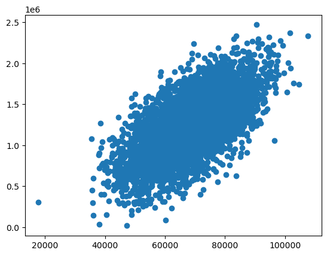

```python
plt.scatter(USA_Housing['Avg. Area Income'],USA_Housing['Price'])
```

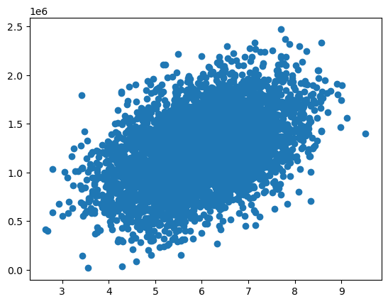

```python
plt.scatter(USA_Housing['Avg. Area House Age'],USA_Housing['Price'])
```

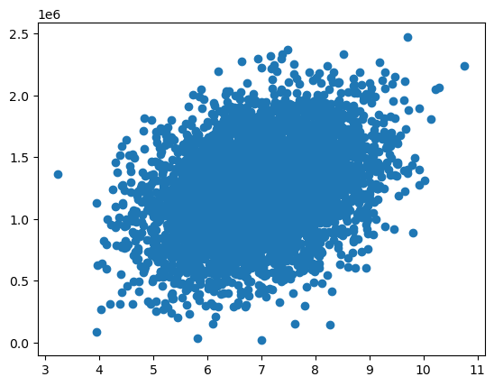

```python
plt.scatter(USA_Housing['Avg. Area Number of Rooms'],USA_Housing['Price'])
```

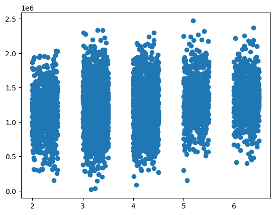

```python
plt.scatter(USA_Housing['Avg. Area Number of Bedrooms'],USA_Housing['Price'])
```

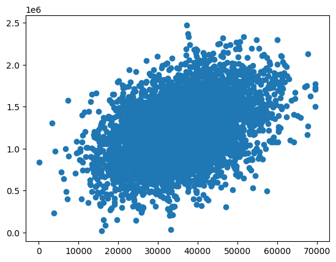

```python
plt.scatter(USA_Housing['Area Population'],USA_Housing['Price'])
```

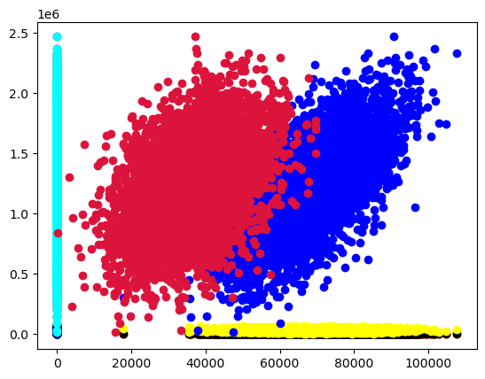

```python
plt.scatter(USA_Housing['Avg. Area Income'],USA_Housing['Avg. Area House Age'],color='red')
plt.scatter(USA_Housing['Avg. Area Income'],USA_Housing['Avg. Area Number of Rooms'],color='orange')
plt.scatter(USA_Housing['Avg. Area Income'],USA_Housing['Avg. Area Number of Bedrooms'],color='black')
plt.scatter(USA_Housing['Avg. Area Income'],USA_Housing['Area Population'],color='yellow')
plt.scatter(USA_Housing['Avg. Area Income'],USA_Housing['Price'],color='blue')
plt.scatter(USA_Housing['Avg. Area House Age'],USA_Housing['Avg. Area Number of Rooms'],color='green')
plt.scatter(USA_Housing['Avg. Area House Age'],USA_Housing['Avg. Area Number of Bedrooms'],color='pink')
plt.scatter(USA_Housing['Avg. Area House Age'],USA_Housing['Area Population'],color='brown')
plt.scatter(USA_Housing['Avg. Area House Age'],USA_Housing['Price'],color='purple')
plt.scatter(USA_Housing['Avg. Area Number of Rooms'],USA_Housing['Avg. Area Number of Bedrooms'],color='gray')
plt.scatter(USA_Housing['Avg. Area Number of Rooms'],USA_Housing['Area Population'],color='teal')
plt.scatter(USA_Housing['Avg. Area Number of Rooms'],USA_Housing['Price'],color='silver')
plt.scatter(USA_Housing['Avg. Area Number of Bedrooms'],USA_Housing['Area Population'],color='navy')
plt.scatter(USA_Housing['Avg. Area Number of Bedrooms'],USA_Housing['Price'],color='aqua')
plt.scatter(USA_Housing['Area Population'],USA_Housing['Price'],color='crimson')
```

# EDA

Let's create some simple plots to check out the data!

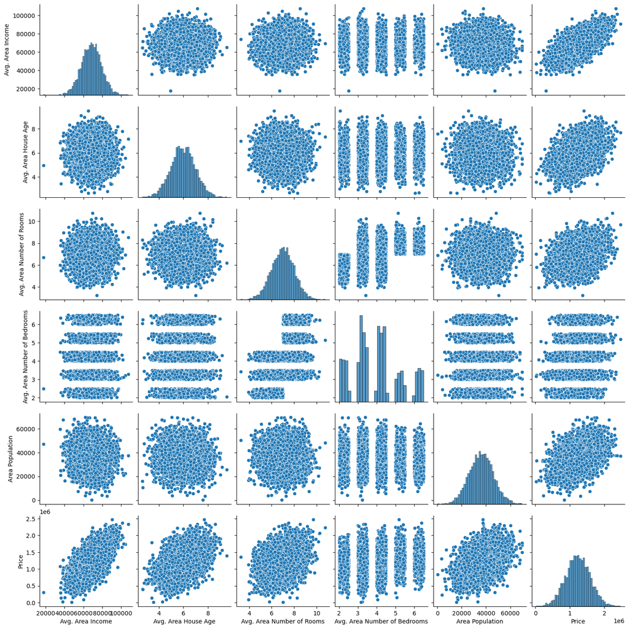

```python
sns.pairplot(USA_Housing)
```

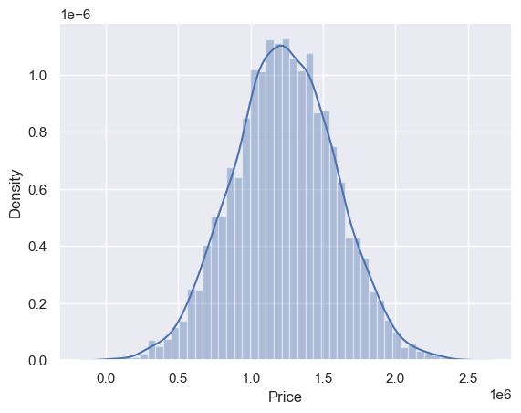

```python
sns.distplot(USA_Housing['Price'])
```

## Training a Linear Regression Model

Let's now begin to train out regression model! We will need to first split up our data into an X array that contains the features to train on, and a y array with the target variable, in this case the Price column. We will toss out the Address column because it only has text info that the linear regression model can't use.

### X and y arrays

```python
X = USA_Housing[['Avg. Area Income', 'Avg. Area House Age', 'Avg. Area Number of Rooms',
               'Avg. Area Number of Bedrooms', 'Area Population']]
y = USA_Housing['Price']
```

## Train Test Split

Now let's split the data into a training set and a testing set. We will train out model on the training set and then use the test set to evaluate the model.

```python
from sklearn.model_selection import train_test_split
```

```python
X = USA_Housing.drop(['Price', 'Address'], axis=1)  # Assuming 'Address' is a feature and dropping it
y = USA_Housing['Price']
```

```python
X_train, X_test, y_train, y_test = train_test_split(X, y, test_size=0.4, random_state=101)
```

```python
print("x_train:-",X_train.shape)
print("x_test:-",X_test.shape)
print("y_train:-",y_train.shape)
print("y_test:-",y_test.shape)
```

```
x_train:- (3000, 5)
x_test:- (2000, 5)
y_train:- (3000,)
y_test:- (2000,)
```

```python
X_train
```

|  | Avg. Area Income | Avg. Area House Age | Avg. Area Number of Rooms | Avg. Area Number of Bedrooms | Area Population |
| --- | --- | --- | --- | --- | --- |
| 1303 | 68091.17968 | 5.364208 | 7.502956 | 3.10 | 44557.37966 |
| 1051 | 75729.76555 | 5.580599 | 7.642973 | 4.21 | 29996.01845 |
| 4904 | 70885.42082 | 6.358747 | 7.250241 | 5.42 | 38627.30147 |
| 931 | 73386.40734 | 4.966360 | 7.915453 | 4.30 | 38413.49048 |
| 4976 | 75046.31379 | 5.351169 | 7.797825 | 5.23 | 34107.88862 |
| ... | ... | ... | ... | ... | ... |
| 4171 | 56610.64256 | 4.846832 | 7.558137 | 3.29 | 25494.74030 |
| 599 | 70596.85095 | 6.548274 | 6.539986 | 3.10 | 51614.83014 |
| 1361 | 55621.89910 | 3.735942 | 6.868291 | 2.30 | 63184.61315 |
| 1547 | 63044.46010 | 5.935261 | 5.913454 | 4.10 | 32725.27954 |
| 4959 | 75078.79152 | 7.644779 | 8.440726 | 4.33 | 56148.44932 |

3000 rows × 5 columns

```python
y_train
```

```
1303    1.489648e+06
1051    1.183015e+06
4904    1.547889e+06
931     1.186442e+06
4976    1.340344e+06
            ...
4171    7.296417e+05
599     1.599479e+06
1361    1.102641e+06
1547    8.650995e+05
4959    2.108376e+06
Name: Price, Length: 3000, dtype: float64
```

```python
X_test
```

|  | Avg. Area Income | Avg. Area House Age | Avg. Area Number of Rooms | Avg. Area Number of Bedrooms | Area Population |
| --- | --- | --- | --- | --- | --- |
| 1718 | 66774.99582 | 5.717143 | 7.795215 | 4.32 | 36788.98033 |
| 2511 | 62184.53937 | 4.925758 | 7.427689 | 6.22 | 26008.30912 |
| 345 | 73643.05730 | 6.766853 | 8.337085 | 3.34 | 43152.13958 |
| 2521 | 61909.04144 | 6.228343 | 6.593138 | 4.29 | 28953.92538 |
| 54 | 72942.70506 | 4.786222 | 7.319886 | 6.41 | 24377.90905 |
| ... | ... | ... | ... | ... | ... |
| 1776 | 65173.05044 | 7.679469 | 6.602618 | 4.23 | 44125.54078 |
| 4269 | 42969.65939 | 6.295501 | 7.885507 | 4.38 | 29594.08986 |
| 1661 | 48735.92451 | 5.543730 | 6.091906 | 2.43 | 19682.34729 |
| 2410 | 65081.58405 | 5.433570 | 9.212518 | 5.14 | 37594.49346 |
| 2302 | 65969.70704 | 7.325976 | 8.020966 | 4.09 | 61772.75681 |

2000 rows × 5 columns

```python
y_test
```

```
1718    1.251689e+06
2511    8.730483e+05
345     1.696978e+06
2521    1.063964e+06
54      9.487883e+05
            ...
1776    1.489520e+06
4269    7.777336e+05
1661    1.515271e+05
2410    1.343824e+06
2302    1.906025e+06
Name: Price, Length: 2000, dtype: float64
```

## Creating and Training the Model

```python
from sklearn.linear_model import LinearRegression
LR=LinearRegression()
```

```python
LR.fit(X_train , y_train)
```

```
LinearRegression()
```

## Model Evaluation

Let's evaluate the model by checking out it's coefficients and how we can interpret them.

```python
# print the intercept
print(LR.intercept_)
```

```
-2640159.796813241
```

```python
coeff_df = pd.DataFrame(LR.coef_,X.columns,columns=['Coefficient'])
coeff_df
```

|  | Coefficient |
| --- | --- |
| Avg. Area Income | 21.528276 |
| Avg. Area House Age | 164883.282027 |
| Avg. Area Number of Rooms | 122368.678023 |
| Avg. Area Number of Bedrooms | 2233.801864 |
| Area Population | 15.150420 |

Interpreting the coefficients:

- Holding all other features fixed, a 1 unit increase in **Avg. Area Income** is associated with an **increase of \$21.52** .
- Holding all other features fixed, a 1 unit increase in **Avg. Area House Age** is associated with an **increase of \$164883.28** .
- Holding all other features fixed, a 1 unit increase in **Avg. Area Number of Rooms** is associated with an **increase of \$122368.67** .
- Holding all other features fixed, a 1 unit increase in **Avg. Area Number of Bedrooms** is associated with an **increase of \$2233.80** .
- Holding all other features fixed, a 1 unit increase in **Area Population** is associated with an **increase of \$15.15** .

Does this make sense? Probably not because I made up this data. If you want real data to repeat this sort of analysis, check out the [boston dataset](http://scikit-learn.org/stable/modules/generated/sklearn.datasets.load_boston.html):

## Predictions from our Model

Let's grab predictions off our test set and see how well it did!

```python
predictions = LR.predict(X_test)
```

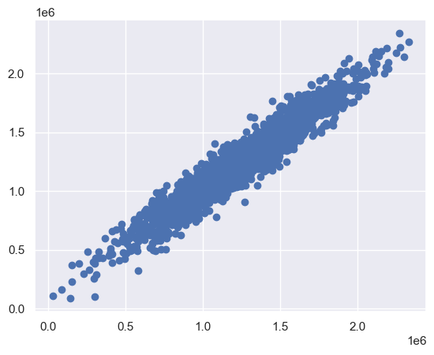

```python
plt.scatter(y_test,predictions)
```

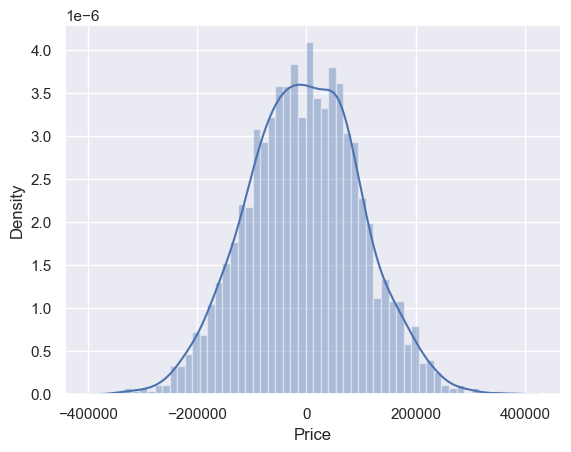

```python
sns.distplot((y_test-predictions),bins=50);
```

## Regression Evaluation Metrics

Here are three common evaluation metrics for regression problems:

**Mean Absolute Error** (MAE) is the mean of the absolute value of the errors:

$$\frac 1n\sum_{i=1}^n|y_i-\hat{y}_i|$$

**Mean Squared Error** (MSE) is the mean of the squared errors:

$$\frac 1n\sum_{i=1}^n(y_i-\hat{y}_i)^2$$

**Root Mean Squared Error** (RMSE) is the square root of the mean of the squared errors:

$$\sqrt{\frac 1n\sum_{i=1}^n(y_i-\hat{y}_i)^2}$$

Comparing these metrics:

- **MAE** is the easiest to understand, because it's the average error.
- **MSE** is more popular than MAE, because MSE "punishes" larger errors, which tends to be useful in the real world.
- **RMSE** is even more popular than MSE, because RMSE is interpretable in the "y" units.

All of these are **loss functions**, because we want to minimize them.

```python
from sklearn import metrics

print('MAE:', metrics.mean_absolute_error(y_test, predictions))
print('MSE:', metrics.mean_squared_error(y_test, predictions))
print('RMSE:', np.sqrt(metrics.mean_squared_error(y_test, predictions)))
```

```
MAE: 82288.22250721784
MSE: 10460958905.775045
RMSE: 102278.82921589905
```

# Model Evaluation & Optimization

# Find Acc for LR_Model

```python
#Find Acc for LR_Model
acc = LR.score(X_test , y_test)
print("LR_Model acc :- ",acc*100)
```

```
LR_Model acc :-  91.76824009781832
```

# Predictions

```python
LR.fit(X_train.values, y_train.values)
data_pred = LR.predict(X_test.values)
```

```python
data_pred
```

```
array([1260960.70581766,  827588.7554465 , 1742421.24257427, ...,
        372191.4061303 , 1365217.15136993, 1914519.54191725])
```

```python
data_pred[0]
```

```
1260960.7058176612
```